# Exploring Diamonds

Tomás

March 22, 2016

## Diamonds Data Set - Exploring the Data

#### Skipping Ahead

If you’d like to see certain sections - click on the link below.

Springboard Assignment Plot

### Overview of the Dataset

We’ll first explore the dataset of diamonds to see what we are dealing with. A few starters when first dealing with a df is to load it from the ggplot library `df <- tbl_df(diamonds)`

To get a better understanding, we’ll run a few basic commands: `str(), head(), summary() (or dplyr::glimpse())`

```r
names(df)
```

```
##  [1] "carat"   "cut"     "color"   "clarity" "depth"   "table"   "price"
##  [8] "x"       "y"       "z"
```

```r
str(df)
```

```
## Classes 'tbl_df', 'tbl' and 'data.frame':    53940 obs. of  10 variables:
##  $ carat  : num  0.23 0.21 0.23 0.29 0.31 0.24 0.24 0.26 0.22 0.23 ...
##  $ cut    : Ord.factor w/ 5 levels "Fair"<"Good"<..: 5 4 2 4 2 3 3 3 1 3 ...
##  $ color  : Ord.factor w/ 7 levels "D"<"E"<"F"<"G"<..: 2 2 2 6 7 7 6 5 2 5 ...
##  $ clarity: Ord.factor w/ 8 levels "I1"<"SI2"<"SI1"<..: 2 3 5 4 2 6 7 3 4 5 ...
##  $ depth  : num  61.5 59.8 56.9 62.4 63.3 62.8 62.3 61.9 65.1 59.4 ...
##  $ table  : num  55 61 65 58 58 57 57 55 61 61 ...
##  $ price  : int  326 326 327 334 335 336 336 337 337 338 ...
##  $ x      : num  3.95 3.89 4.05 4.2 4.34 3.94 3.95 4.07 3.87 4 ...
##  $ y      : num  3.98 3.84 4.07 4.23 4.35 3.96 3.98 4.11 3.78 4.05 ...
##  $ z      : num  2.43 2.31 2.31 2.63 2.75 2.48 2.47 2.53 2.49 2.39 ...
```

```r
head(df)
```

```
## Source: local data frame [6 x 10]
##
##   carat       cut  color clarity depth table price     x     y     z
##   (dbl)    (fctr) (fctr)  (fctr) (dbl) (dbl) (int) (dbl) (dbl) (dbl)
## 1  0.23     Ideal      E     SI2  61.5    55   326  3.95  3.98  2.43
## 2  0.21   Premium      E     SI1  59.8    61   326  3.89  3.84  2.31
## 3  0.23      Good      E     VS1  56.9    65   327  4.05  4.07  2.31
## 4  0.29   Premium      I     VS2  62.4    58   334  4.20  4.23  2.63
## 5  0.31      Good      J     SI2  63.3    58   335  4.34  4.35  2.75
## 6  0.24 Very Good      J    VVS2  62.8    57   336  3.94  3.96  2.48
```

```r
summary(df)
```

```
##      carat               cut        color        clarity
##  Min.   :0.2000   Fair     : 1610   D: 6775   SI1    :13065
##  1st Qu.:0.4000   Good     : 4906   E: 9797   VS2    :12258
##  Median :0.7000   Very Good:12082   F: 9542   SI2    : 9194
##  Mean   :0.7979   Premium  :13791   G:11292   VS1    : 8171
##  3rd Qu.:1.0400   Ideal    :21551   H: 8304   VVS2   : 5066
##  Max.   :5.0100                     I: 5422   VVS1   : 3655
##                                     J: 2808   (Other): 2531
##      depth           table           price             x
##  Min.   :43.00   Min.   :43.00   Min.   :  326   Min.   : 0.000
##  1st Qu.:61.00   1st Qu.:56.00   1st Qu.:  950   1st Qu.: 4.710
##  Median :61.80   Median :57.00   Median : 2401   Median : 5.700
##  Mean   :61.75   Mean   :57.46   Mean   : 3933   Mean   : 5.731
##  3rd Qu.:62.50   3rd Qu.:59.00   3rd Qu.: 5324   3rd Qu.: 6.540
##  Max.   :79.00   Max.   :95.00   Max.   :18823   Max.   :10.740
##
##        y                z
##  Min.   : 0.000   Min.   : 0.000
##  1st Qu.: 4.720   1st Qu.: 2.910
##  Median : 5.710   Median : 3.530
##  Mean   : 5.735   Mean   : 3.539
##  3rd Qu.: 6.540   3rd Qu.: 4.040
##  Max.   :58.900   Max.   :31.800
##
```

Let’s answer some basic questions.

- Number of observations: 53940
- Number of variables: 10
- Columns formatted as an ordered factor: (cut, color, clarity)
- Best color for a diamond (aka highest factor of color): D

### Exploring the Price

Next up, we’ll have a look at the different prices of the diamonds and what affects that.

First, let’s see what the full distribution of all the prices of all diamonds looks like.

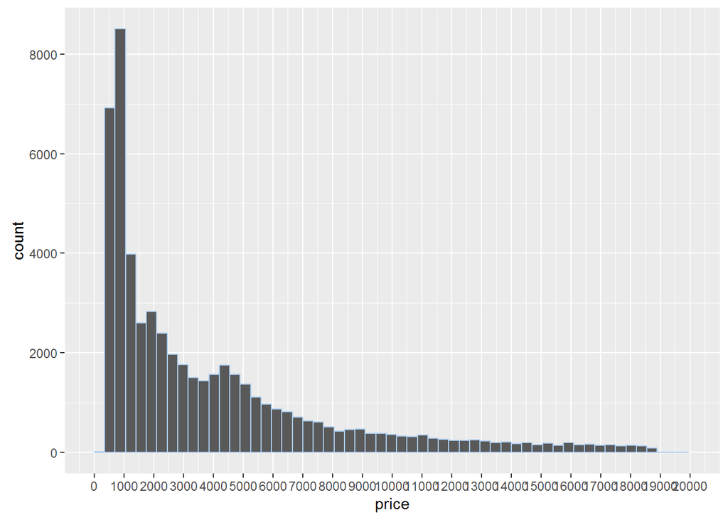

What does this tell us about the data? It seems to be right-skewed data, with the center around 1000

A better plot to evaluate this better would be a boxplot. Let’s do it!

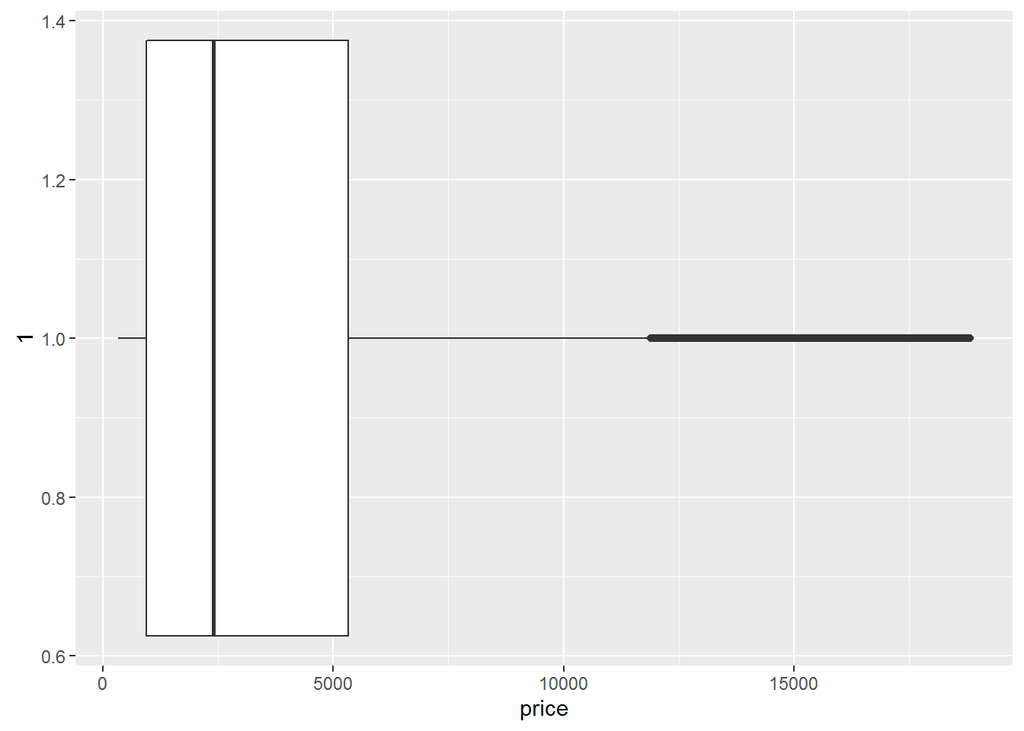

Looking at the plot, though, it appears we have an extremely long tail. Let’s try and cut that down to see a little better of what’s going on.

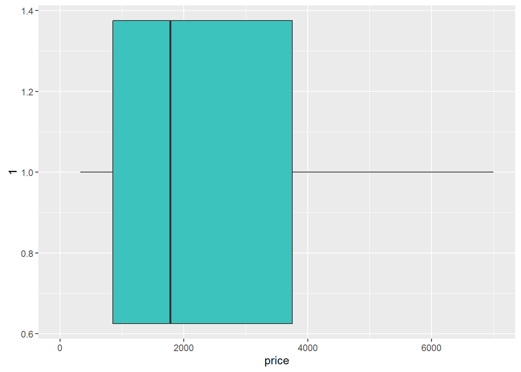

### Breaking Down the Price

If we want to get a closer look into the different costs, let’s get a feel for the edges of our data.

Recall, there are 53940 observations in the data.

- Number of diamonds less than 500: 1729
- Number of diamonds less than 250: 0
- Number of diamonds $15,000 or more: 1656

### Cheaper Diamonds

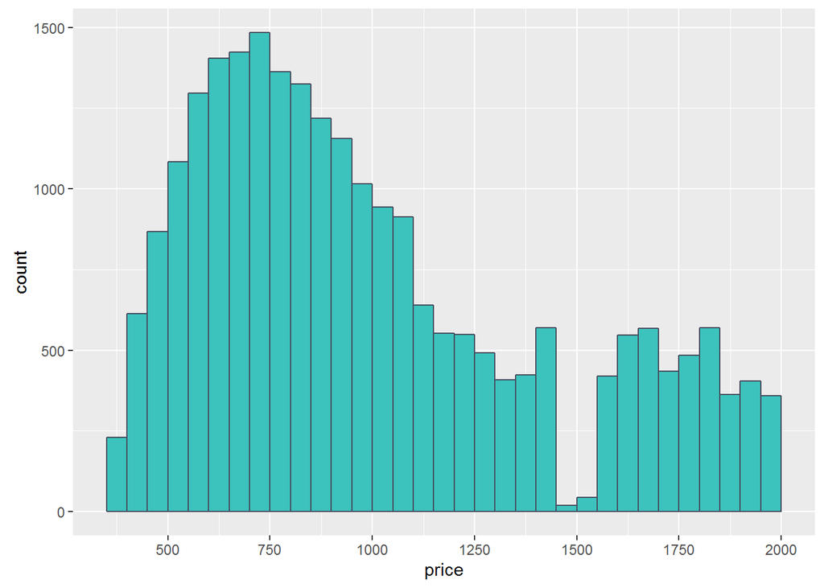

Once the histogram has the x and y-axis cropped, it is a little easier to dissect and understand what we’re looking at.

First, we can easily tell there’s no diamond that costs $1500… odd. Perhaps it’s an even price that companies avoid?

Second, the range of prices most common are between $400 and $1200, at least that’s what it looks like when viewing the graph.

Lastly, the highest frequency of price of a diamond is between $700 and $750.

It makes sense that some factor is driving this price up. First, we’ll explore the cut and how the price changes.

### Price Cut by Histograms

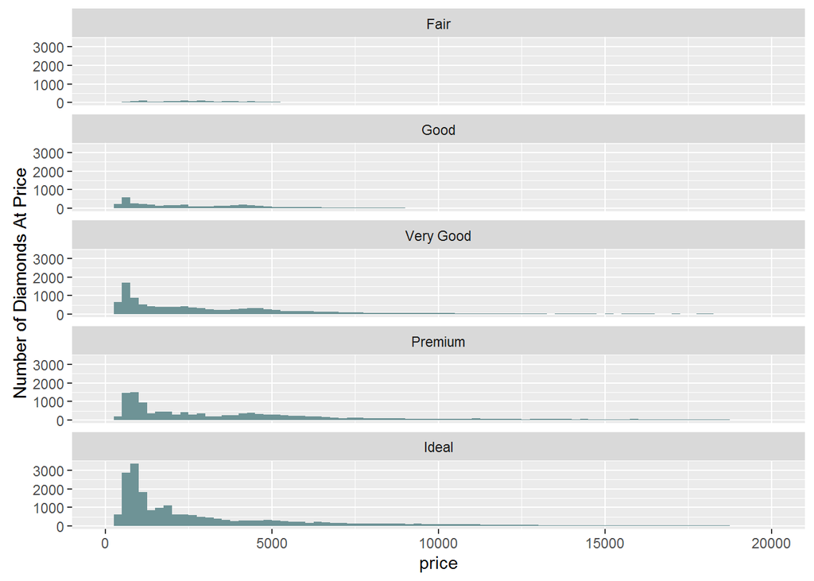

```r
p + geom_histogram(binwidth = 250, fill = "#6e9396") +
  scale_x_continuous(breaks = seq(0, 20000, 5000), limits = c(0, 20000)) +
  facet_wrap(~cut, ncol =1) +
  ylab("Number of Diamonds At Price")
```

These graphs quickly show how most of the diamonds have either a premium or ideal cut have the highest frequency of all diamonds. The $1500 blank spot also sticks out.

Let’s break down some of the prices by category.

Price per Cut Information (Maximum, Minimum, and Median):

```
## Source: local data frame [5 x 5]
##
##         cut Max Price Min Price Median Price Mean Price
##      (fctr)     (int)     (int)        (dbl)      (dbl)
## 1      Fair     18574       337       3282.0   4358.758
## 2      Good     18788       327       3050.5   3928.864
## 3 Very Good     18818       336       2648.0   3981.760
## 4   Premium     18823       326       3185.0   4584.258
## 5     Ideal     18806       326       1810.0   3457.542
```

However, each cut seems to have a similar distribution of prices. Let’s see if we can’t adjust the scales to give us a better graph.

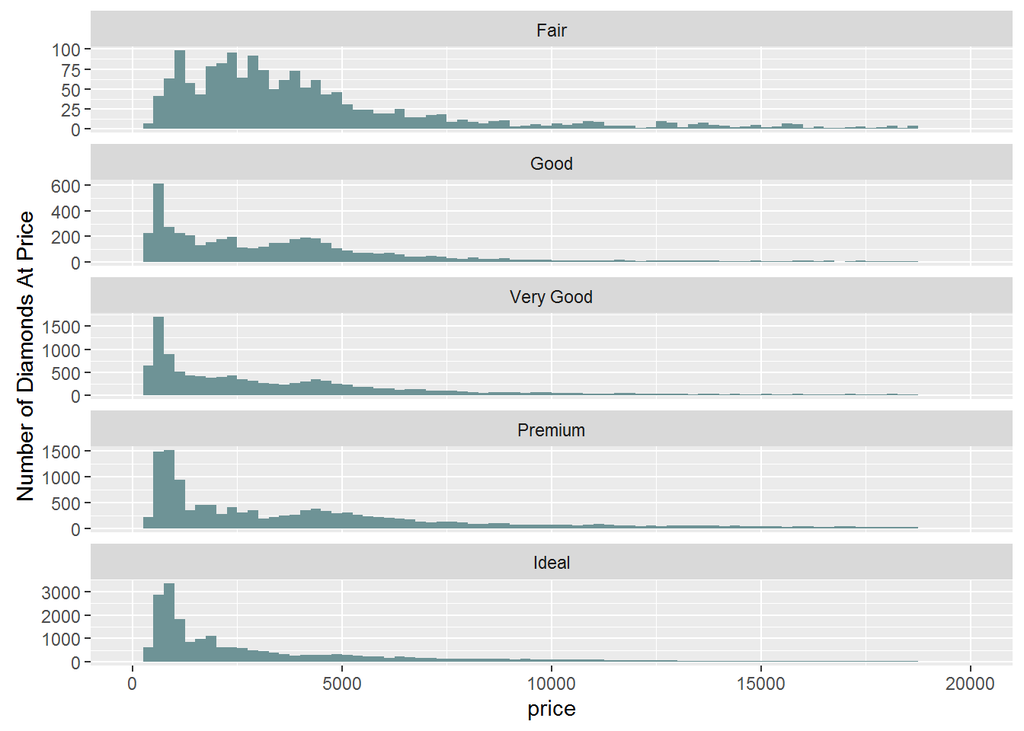

```r
p + geom_histogram(binwidth = 250, fill = "#6e9396") +
  scale_x_continuous(breaks = seq(0, 20000, 5000), limits = c(0, 20000)) +
  facet_wrap(~cut, ncol = 1, scales = "free_y") +
  ylab("Number of Diamonds At Price")
```

Looks better. Let’s continue our exploration.

### Price Per Carat by Cut

It would be a mistake to only look at one variable as a driving factor for the price. If we adjust the data to look at how price varies per carat and by cut, we may get a better understanding of the diamond market.

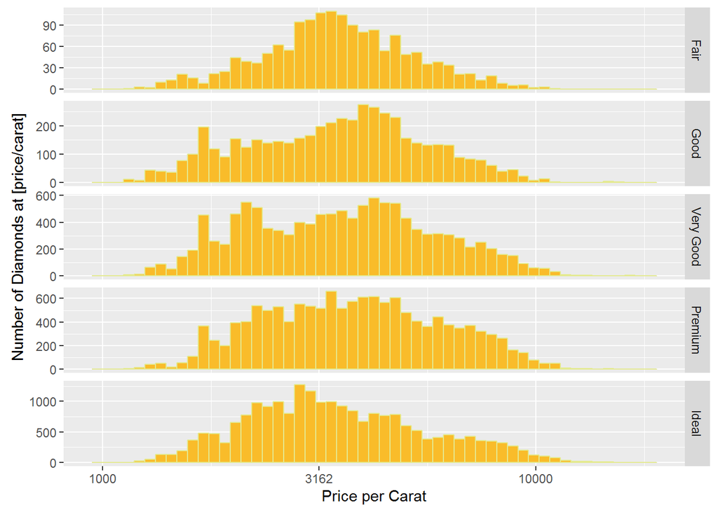

“Very Good” has an interesting distribution - almost bimodal (2nd peak being around $4500/carat).

### Price Box Plots

Let’s try looking at the price as it varies by clarity. We’ll use a boxplot to investigate how this one works.

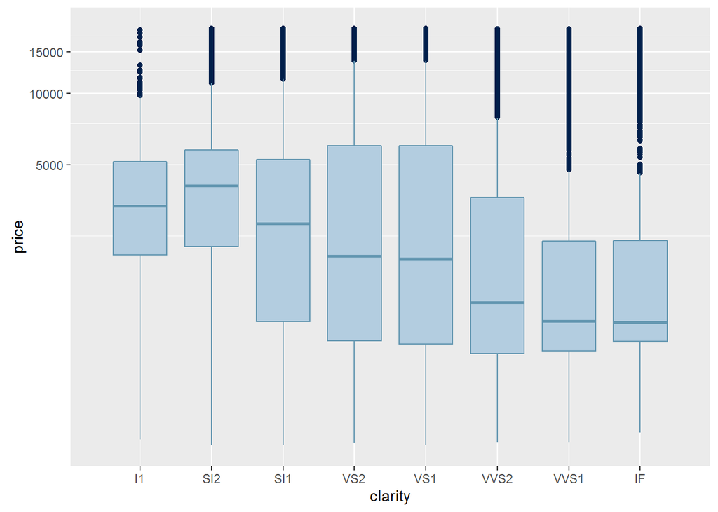

```
## Source: local data frame [8 x 5]
##
##   clarity  Mean Median   Max Count
##    (fctr) (dbl)  (dbl) (int) (int)
## 1      IF  2865   1080 18806  1790
## 2    VVS1  2523   1093 18777  3655
## 3    VVS2  3284   1311 18768  5066
## 4     VS1  3839   2005 18795  8171
## 5     VS2  3925   2054 18823 12258
## 6     SI1  3996   2822 18818 13065
## 7     SI2  5063   4072 18804  9194
## 8      I1  3924   3344 18531   741
```

What this might be telling us is even though IF has the best clarity, it also has one of the lowest median prices. The prices for VVSI and IF even keep their 3rd quartile prices below $2500. The bulk number of the diamonds do not fall in this category either, so this may indicate an area where you can get the best quality at a “low” price? The low count on these diamonds, however, may hint towards them being very rare and there is not much of a market for them? Or possibly the other variables influence the price much more - so while the better the clarity, the higher the price, the other variables affect the price at a much greater scale? We’ll have to take a closer look.

VS2, and SI1 make up the bulk of the diamonds and may indicate what you should expect from a diamond with less-than flawless diamonds.

### A Closer Look

Let’s go through some of the different factors to see we can understand why an IF and VVS1 have the lowest median costs.

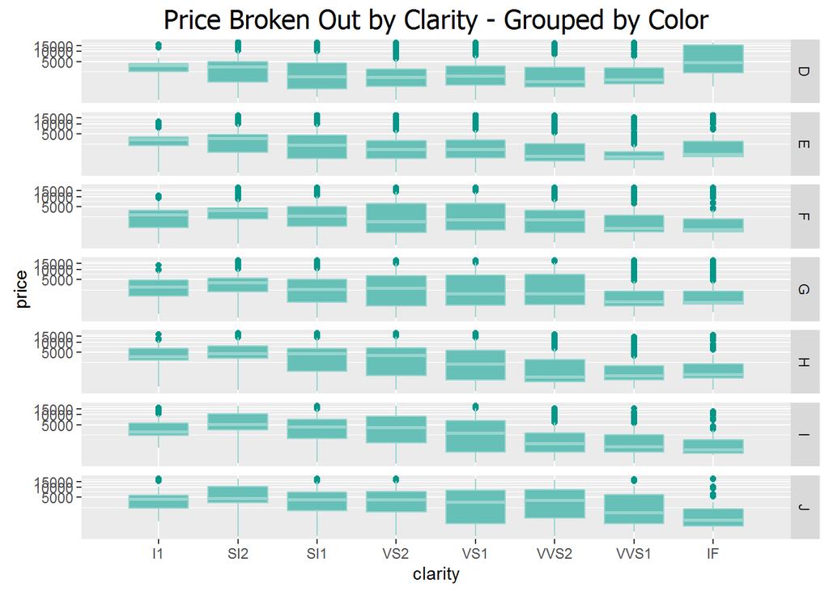

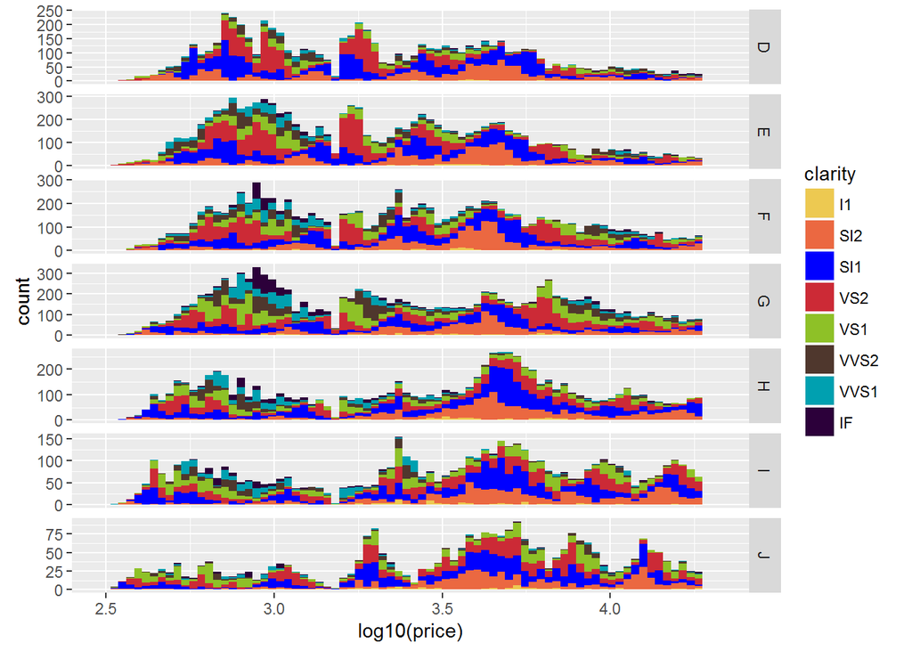

Let’s also look at the previous plot to see how carat plays a role.

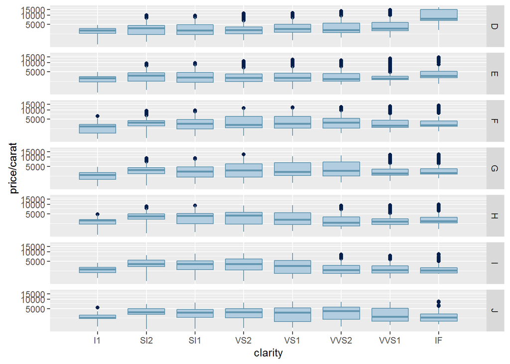

Looking at the graph above, the pricing starts to make more sense with regard to the clarity.

As the diamonds get closer to the best of clarity and color, the price/carat increases - as would be expected. The closer to a “D” flawless (“IF”) diamond you get, the more money you’ll have to fork over. This is only a preliminary look though, as there are still other variables to explore as how they affect price, but will be covered at a later time.

### Interquartile Range - IQR

To understand a little more of how the diamonds price varies between colors, we’ll have a closer look at their distributions.

| IQR - [Color] | Price |
| --- | --- |
| 1st Quartile [D] | 911 |
| 3rd Quartile [D] | 4213.5 |
| 1st Quartile [J] | 1860.5 |
| 3rd Quartile [J] | 7695 |
| IQR [D] | 3302.5 |
| IQR [J] | 5834.5 |

### Price per Carat by Color

Above, we looked at the price per carat by cut. What about another part of the “4 C’s” - color?

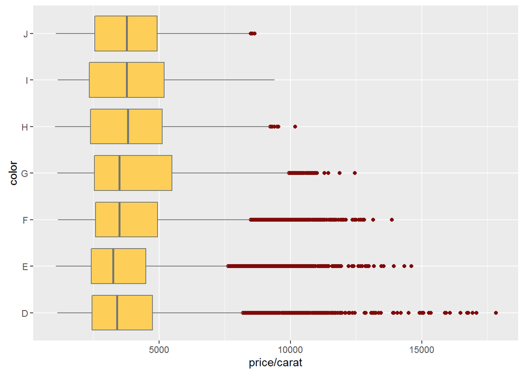

We’ve been looking at some of the points on a scale of $/carat, but what does the carat weight of the ring actually tell us? Which are the most common weights?

We’ll set a threshold value of 2000. This means, if there are more than 2000 diamonds of one carat size, we should know about it.

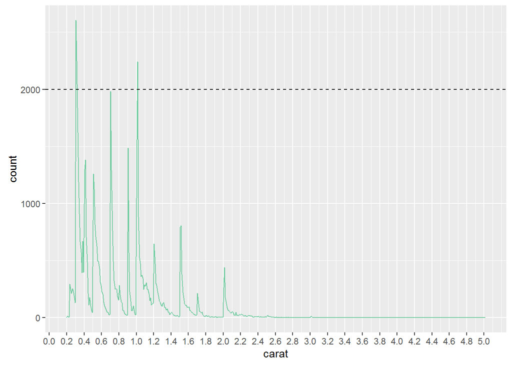

```
## Source: local data frame [3 x 2]
##
##   carat count
##   (dbl) (int)
## 1  0.30  2604
## 2  0.31  2249
## 3  1.01  2242
```

So there you have it - the most popular diamond weight is 0.30, 0.31, and 1.01.

### Final Thoughts and Future Work

The primary focus of this exploration was to better understand how multiple variables can affect the outcome - price. We primarily focused on the “4 C’s” of the diamond, but there were still additional variables to explore.

If we were to continue analyzing the data here, by determining the relationship between *ALL* the variables, we should be able to put together a full model on expected price based on the different variables. This could be a handy tool for any persons out there shopping for diamond rings and hoping to get a good deal, or at least not ripped off.